# R Notebook

##### Box Plots

Box plots, also known as box-and-whisker plots, provide a visual summary of the distribution of a dataset. They display the median, quartiles, and any potential outliers. A box plot aids in identifying outliers.

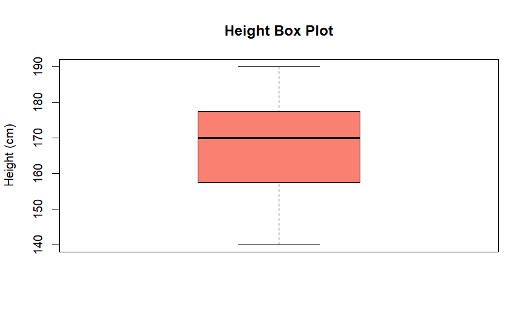

```r
# Create a box plot
heights <- c(160, 170, 175, 150, 185, 165, 170, 155, 180, 190, 140)
boxplot(heights, main = "Height Box Plot", ylab = "Height (cm)", col = "salmon")
```

The box plot represents the five-number summary of the data: minimum, first quartile (Q1), median, third quartile (Q3), and maximum. The “box” itself spans from Q1 to Q3, with a line inside representing the median. The “whiskers” extend to the minimum and maximum values within 1.5 times the interquartile range (IQR) from the box. Points beyond the whiskers are considered potential outliers.

##### Pie chart

Pie charts display the proportion of different categories in a dataset. They are suitable for illustrating relative contributions or shares.

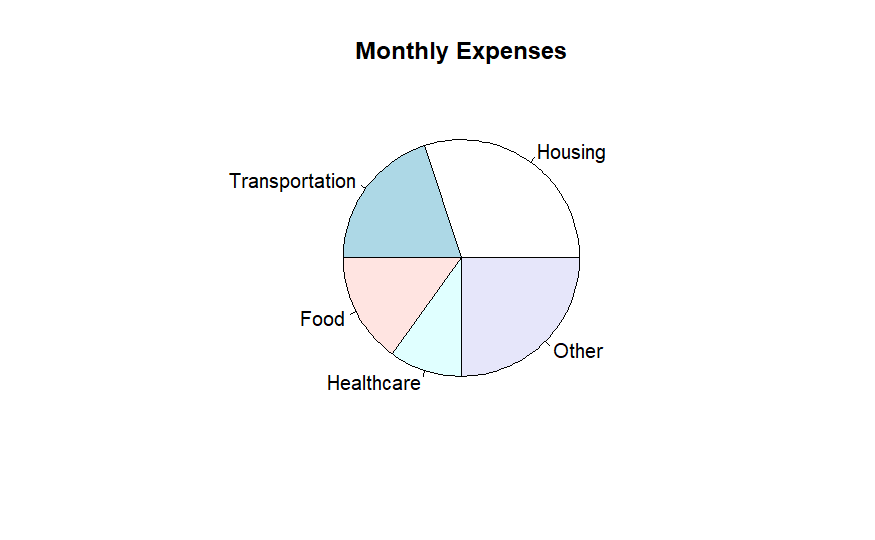

```r
# Create a pie chart
# named vector
expenses <- c(Housing = 30, Transportation = 20, Food = 15, Healthcare = 10, Other = 25)
pie(expenses, main = "Monthly Expenses")
```

In this example, the expenses vector contains the percentages of various expense categories. The pie() function creates a pie chart illustrating the distribution of expenses.

##### Line plots

Line plots are used to visualize trends or changes in a dataset over time or another continuous variable. They are commonly used in economics to represent time series data such as stock prices, GDP growth, or inflation rates.

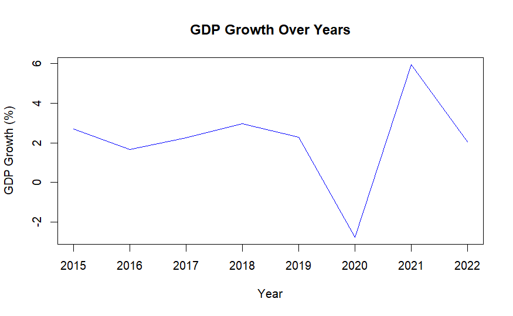

```r
# Create a line plot
years <- c(2015, 2016, 2017, 2018, 2019, 2020, 2021, 2022)

# https://www.macrotrends.net/countries/USA/united-states/gdp-growth-rate#:~:text=U.S.%20GDP%20Growth%20Rate%20-%20Historical%20Data%20,%20%20-0.65%25%20%2058%20more%20rows%20
gdp_growth <- c(2.71, 1.67, 2.24, 2.95, 2.29, -2.77, 5.95, 2.06)
plot(years, gdp_growth, type = "l", main = "GDP Growth Over Years",
     xlab = "Year", ylab = "GDP Growth (%)", col = "blue")
```

#### Scatterplot

Scatterplots are used to visualize the relationship between two continuous variables. Each data point is represented as a point on the plot, with one variable on the x-axis and the other on the y-axis.

Scatterplots help identify patterns, trends, and the strength of the relationship between the two variables. They play a key role in regression analysis and thus econometrics.

```r
# Load the built-in iris dataset
data(iris)

# Create a scatterplot of sepal length vs. sepal width
plot(x=iris$Sepal.Length, y=iris$Sepal.Width,
     type = "p",  # "p" for points
     col = iris$Species,  # Color points by species
     pch = 19,  # Point shape (filled circle)
     xlab = "Sepal Length",
     ylab = "Sepal Width",
     main = "Scatterplot of Sepal Length vs. Sepal Width by Species"
)

# Add a legend
legend("topright", legend = levels(iris$Species),
       col = 1:3, pch = 19, title = "Species")
```

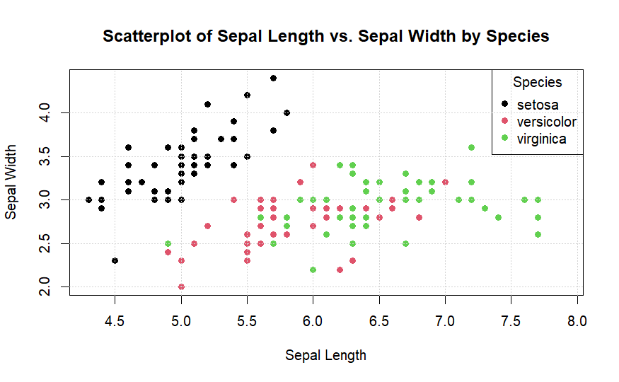

```r
# Add a grid (optional)
grid()
```

**Exercise 5:** Create a pie chart to show the distribution of the budget allocated to different sectors (Education, Defense, Healthcare, Infrastructure, Others) in a government’s annual budget. Use arbitrary percentages for the sectors.

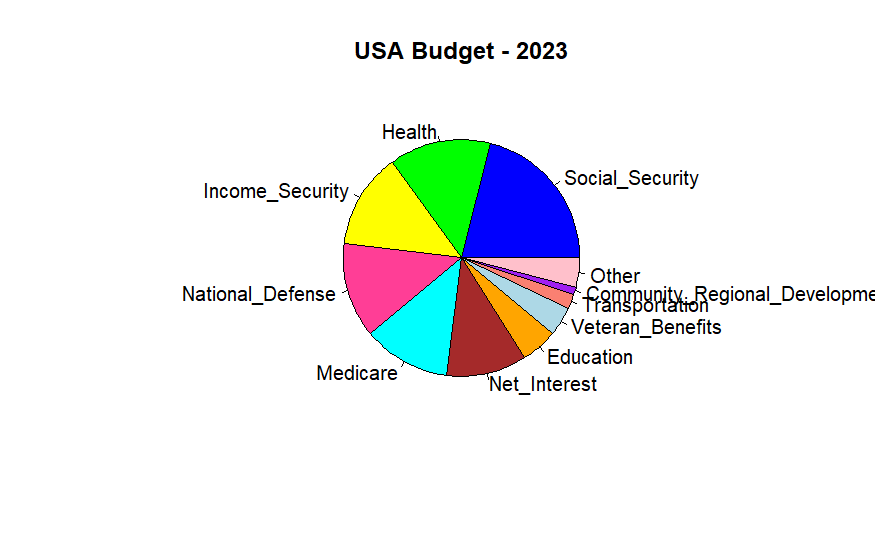

```r
# https://fiscaldata.treasury.gov/americas-finance-guide/federal-spending/
econ_sectors <- c(Social_Security=21, Health=14, Income_Security=13, National_Defense=13, Medicare=12, Net_Interest=11, Education=5, Veteran_Benefits=4, Transportation=2, Community_Regional_Development=1, Other=4)

# https://www.nceas.ucsb.edu/sites/default/files/2020-04/colorPaletteCheatsheet.pdf
pie(econ_sectors,
    main="USA Budget - 2023",
    radius=0.8,
    col=c("blue", 'green', "yellow", "violetred1", "cyan",
          "brown", 'orange', 'lightblue','salmon', "purple", "pink"))
```

##### Functions in R

Functions are blocks of code that can be reused for specific tasks. A function has a name and is preceded by the reserved word function(). Functions are essential for organizing and reusing code. They encapsulate a set of instructions under a single name for easy invocation.

```r
# Define a function
calculate_mean <- function(data) {
  mean_value <- mean(data)
  return(mean_value)
}

# Use the function
income <- c(45000, 48000, 52000, 60000, 67000)
mean_income <- calculate_mean(income)
print(paste("Mean Income:", mean_income))
```

```
[1] "Mean Income: 54400"
```

In the above example, we defined a function calculate_mean() that takes a dataset as input and returns the mean value. This makes it easier to compute the mean for different datasets.

**Exercise 2:** Economic Analysis with Functions

Imagine you’re an economist analyzing inflation rates over the past few years. You have the following data representing annual inflation rates (%):

```r
inflation_rates <- c(2.1, 1.8, 2.5, 2.2, 2.9)
var(inflation_rates)
```

```
[1] 0.175
```

1. Write a function named calculate_avg_var_inflation that takes in the vector of inflation rates as input and returns a report with the average inflation rate and the variance of the input vector.
2. Use the function to calculate the average inflation rate for the provided inflation_rates.

**Solution:**

```r
calculate_avg_var_inflation <- function(data) {
  avg_inflation <- mean(data, na.rm=T)
  var_inflation <- var(data, na.rm=T)

  res <- paste("Average inflation = ", avg_inflation, "; Variance = ", var_inflation)
  return(res)
}

calculate_avg_var_inflation(inflation_rates)
```

```
[1] "Average inflation =  2.3 ; Variance =  0.175"
```